# Lab 01 Initial Work

Audrey Bischoff

1/22/2019

## Comparison of Alcohol Users and Non-users

Our central goal is to illustrate the frequency of alcohol use overall as well as illustrate how the severity of alcohol use differs within alcohol users.

For the purposes of this data, we will define the following terms:

A Current User is a person who has used alcohol in the past 30 days. A Former User is a person who has not used alcohol in the past 30 days. A Non-user is a person who has not used alcohol in their lifetime. A Light User is a person who has drank less than 10 days in the past month. A Moderate User is a person who has drank between 10 and 20 days in the past month. A Heavy User is a person who has drank over 20 days in the past month.

## Description of Data

ALCFLAG - Data which shows if a user has ever used alcohol.

ALCREC - Data which shows the last time a person used alcohol.

ALCYRTOT - Data which shows the frequency of alcohol use in the past year.

ALCDAYS - Data which shows how often a person used alcohol in the past 30 days.

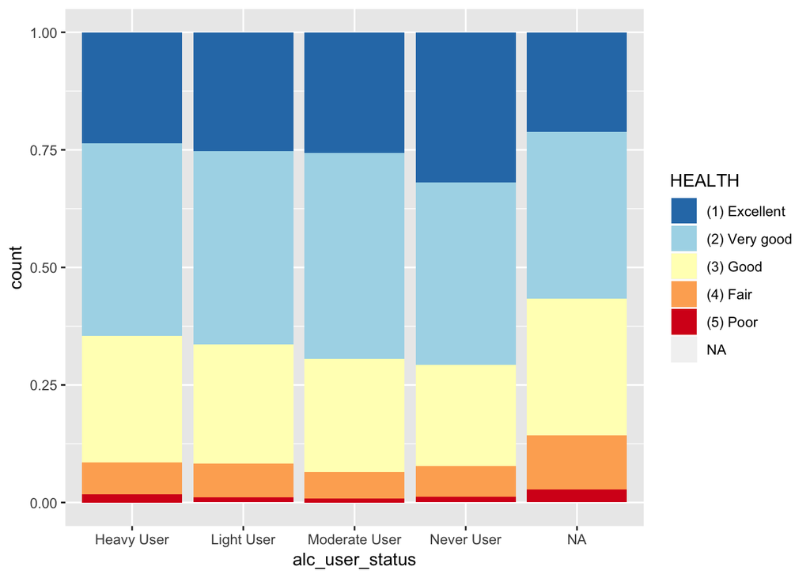

```r
full_data <- mutate(full_data, alc_user_status =
                    ifelse(ALCFLAG == "(0) Never used (IRALCRC = 9)", "Never User",
                           ifelse(ALCMON == "(0) Did not use in the past month (IRALCRC = 2-3,0)",
                                  "Former User", "Current User")))
full_data <- mutate(full_data, alc_30day_use = cut(ALCDAYS, c(0, 10, 20, 30),
                                                   c("Light User", "Moderate User", "Heavy User")))

full_data <- mutate(full_data, alc_user_status = ifelse(alc_user_status =="Current User",
                                                        as.character(alc_30day_use), alc_user_status))

ggplot(full_data)+geom_bar(aes(x=alc_user_status, fill=HEALTH),position="fill")+scale_fill_brewer(palette="RdYlBu", direction=-1)
```

```r
full_data <- mutate(full_data, alc_user_status = as.factor(alc_user_status))

full_data <- mutate(full_data, alc_user_status = fct_relevel(alc_user_status,
                                                            "Never User",
                                                            "Light User",
                                                            "Moderate User",
                                                            "Heavy User"))
```

This graph displays the self-reported overall health of people who are categorized as “heavy,” “light,” “moderate,” or “never” users.

```r
heavy_use_criteria <- 30
light_use_criteria <- 10
```

```r
heavy_users <- filter(full_data, ALCDAYS <= heavy_use_criteria)
light_users <- filter(full_data, ALCDAYS <= light_use_criteria)
```

```r
remove(full_data)

heavy_users <- select(heavy_users, HEALTH)
light_users <- select(light_users, HEALTH)
```

```r
heavy_users$alc_user_status <- "heavy"
light_users$alc_user_status <- "light"
combined_data <- rbind(heavy_users, light_users)
```

## Heavy User Data

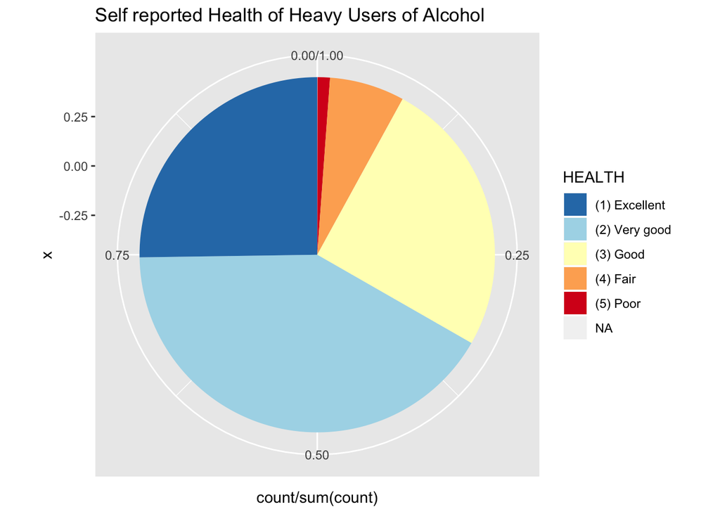

```r
#piegraph
piegraph <- ggplot(heavy_users) + geom_bar(aes(x=0, fill=HEALTH, y=..count../sum(..count..))) + coord_polar(theta="y") + scale_fill_brewer(palette="RdYlBu", direction =-1)
piegraph <- piegraph + labs(title="Self reported Health of Heavy Users of Alcohol")
piegraph
```

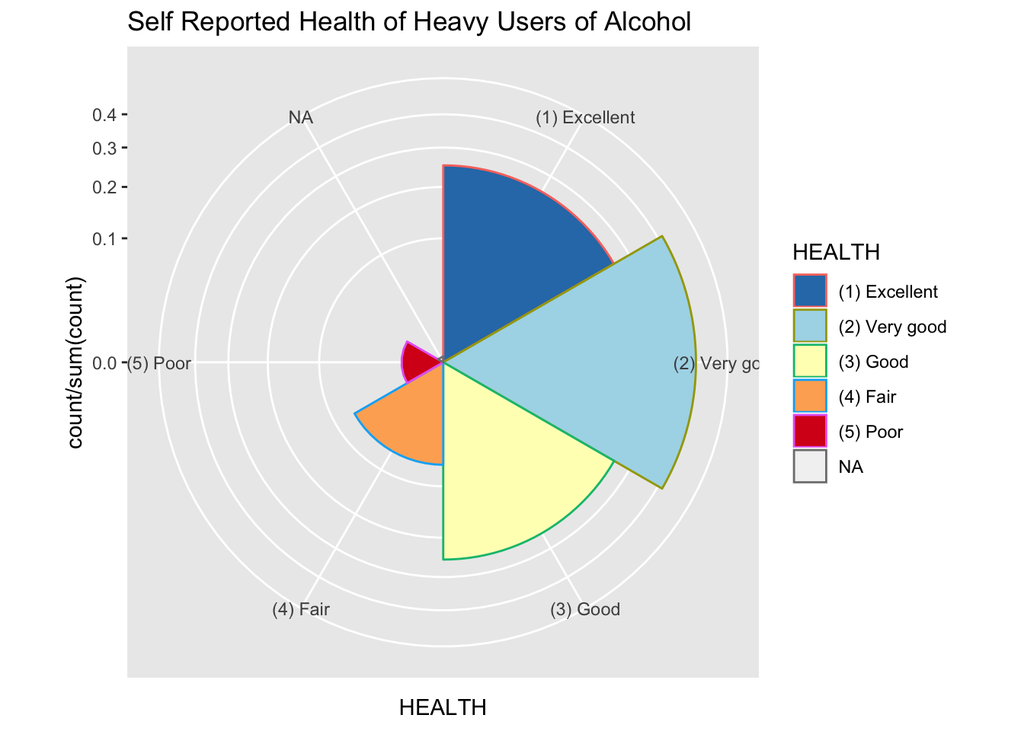

```r
#coxcomb
coxcomb <- ggplot(heavy_users) + geom_bar(aes(x=HEALTH, fill=HEALTH, color=HEALTH, y=..count../sum(..count..)), width=1) + coord_polar()+scale_y_sqrt() + scale_fill_brewer(palette="RdYlBu", direction =-1)
coxcomb <- coxcomb + labs(title="Self Reported Health of Heavy Users of Alcohol")
coxcomb
```

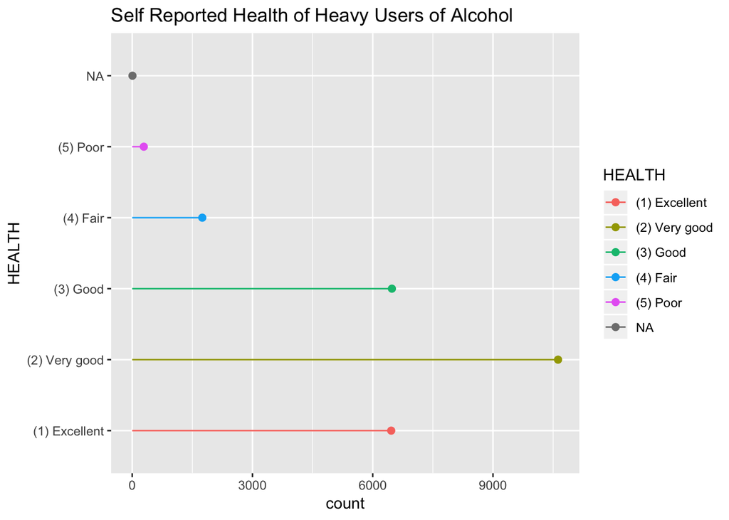

```r
#dot
dot <- ggplot(heavy_users) + geom_segment(aes(x=HEALTH,xend=HEALTH, color=HEALTH),yend=0,stat="count",width=.02) + geom_point(aes(x=HEALTH, color=HEALTH),stat="count",size=2)+
  coord_flip()+ scale_fill_brewer(palette="RdYlBu", direction =-1)
dot <- dot + labs(title="Self Reported Health of Heavy Users of Alcohol")
dot
```

## Light User Data

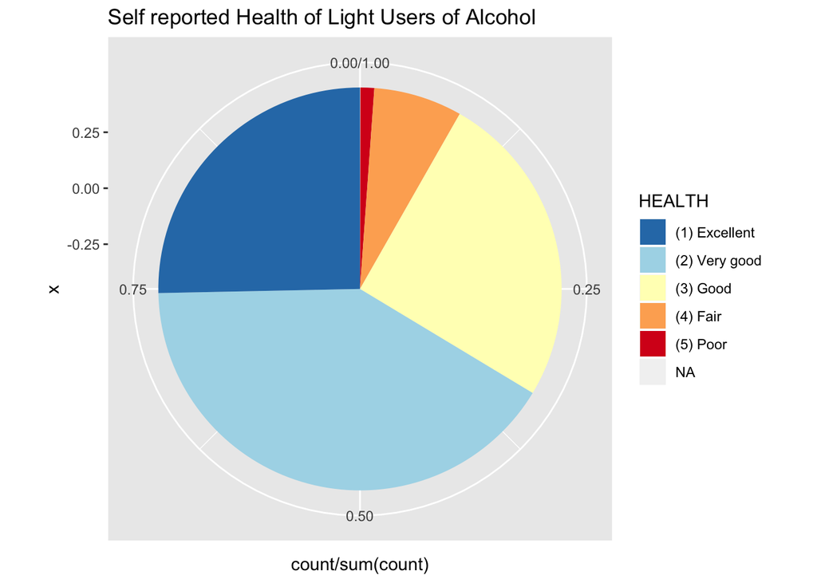

```r
#piegraph
light_user_piegraph <- ggplot(light_users) + geom_bar(aes(x=0, fill=HEALTH, y=..count../sum(..count..))) + coord_polar(theta="y") + scale_fill_brewer(palette="RdYlBu", direction =-1)
light_user_piegraph <- light_user_piegraph + labs(title="Self reported Health of Light Users of Alcohol")
light_user_piegraph
```

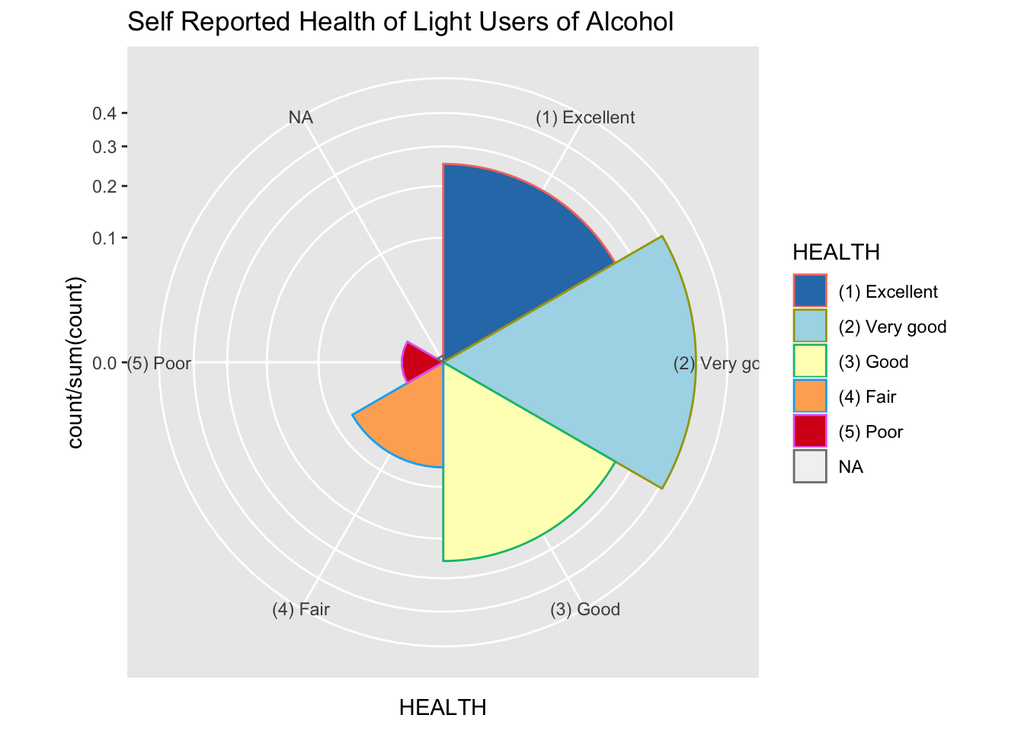

```r
#coxcomb
light_user_coxcomb <- ggplot(light_users) + geom_bar(aes(x=HEALTH, fill=HEALTH, color=HEALTH, y=..count../sum(..count..)), width=1) + coord_polar()+scale_y_sqrt()+ scale_fill_brewer(palette="RdYlBu", direction =-1)
light_user_coxcomb <- light_user_coxcomb + labs(title="Self Reported Health of Light Users of Alcohol")
light_user_coxcomb
```

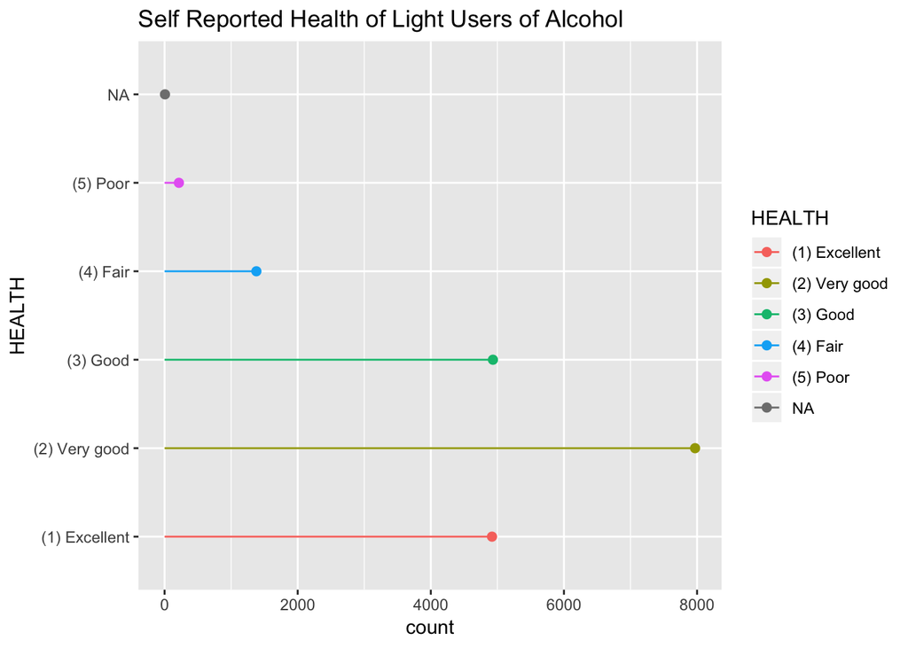

```r
#dot
light_user_dot <- ggplot(light_users) + geom_segment(aes(x=HEALTH,xend=HEALTH, color=HEALTH),yend=0,stat="count",width=.02) + geom_point(aes(x=HEALTH, color=HEALTH),stat="count",size=2)+
  coord_flip()+ scale_fill_brewer(palette="RdYlBu", direction =-1)
light_user_dot <- light_user_dot + labs(title="Self Reported Health of Light Users of Alcohol")
light_user_dot
```